# State MSM Profile: **Florida**

### Background & Methods

In 2015-2016, researchers at Emory University partnered with colleagues at the Centers for Disease Control and Prevention (CDC) to develop methods to estimate the number of men who have sex with men (MSM) residing in each county in the United States. Using population and housing data from the [American Community Survey](https://www.census.gov/programs-surveys/acs/) and estimates from two peer-reviewed publications ([Oster et al., 2015](http://www.ncbi.nlm.nih.gov/pubmed/26115985) & [Purcell et al., 2012](http://www.ncbi.nlm.nih.gov/pubmed/23049658)), they derived an indirect estimate of MSM population sizes that took into account both the urbanicity of the county as well as its density of households with a male householder and a male same-sex partner.

The full methodology is published in the *Journal of Medical Internet Research - Public Health and Surveillance*:

> [Grey JA, Bernstein KT, Sullivan PS, Purcell DW, Chesson HW, Gift TL, Rosenberg ES. Estimating the population sizes of men who have sex with men in US states and counties using data from the American Community Survey. JMIR Public Health Surveill 2016;2(1):e14. DOI: 10.2196/publichealth.5365](http://publichealth.jmir.org/2016/1/e14/)

### Overview of MSM in Florida

An estimated **340,163** men who have sex with men (MSM) resided in Florida in 2013, representing 7.6% of the 4,503,084 MSM in the United States. Of the 7,283,572 adult men of Florida, 4.7% had had sex with another man in the past 5 years, which was greater than the overall percentage of adult men in the United States who were MSM (3.9%).

Most MSM in Florida resided in central counties of large metropolitan areas (47.1%). Including both central and fringe counties, 79.9% resided in a large metropolitan area.

##### **Percentage of MSM by urbanicity, United States and Florida, 2013**

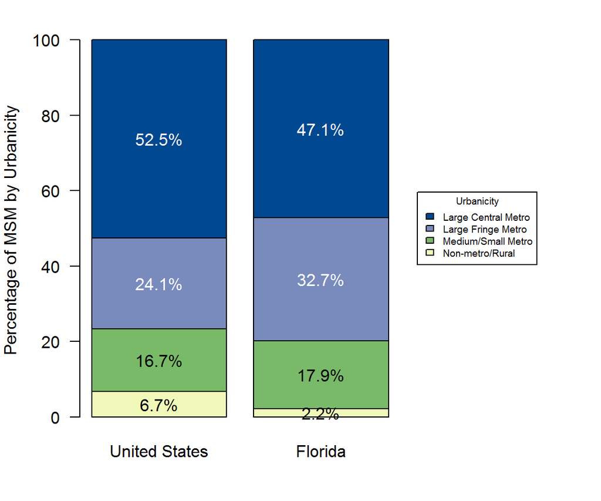

### MSM in Florida Counties

Among counties or county-equivalent areas in Florida, Miami-Dade County had the largest population of MSM at 59,732, representing 17.6% of all MSM in the state. Liberty County had the highest percentage of MSM among adult men in Florida at 12.6%. This was greater than the percentage for Florida as a whole, which was 4.7% of adult men.

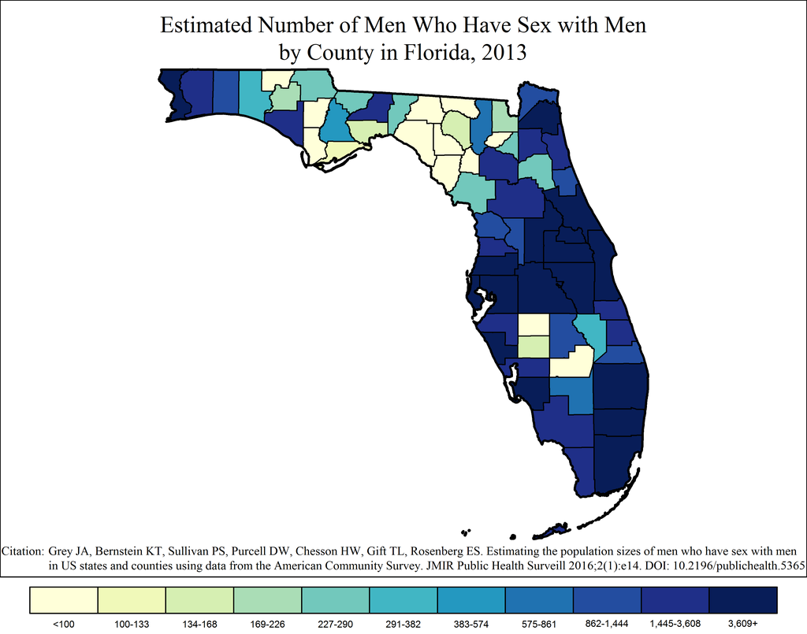

Note: Range cutpoints for the map are based on the distribution of MSM among all counties in the United States.

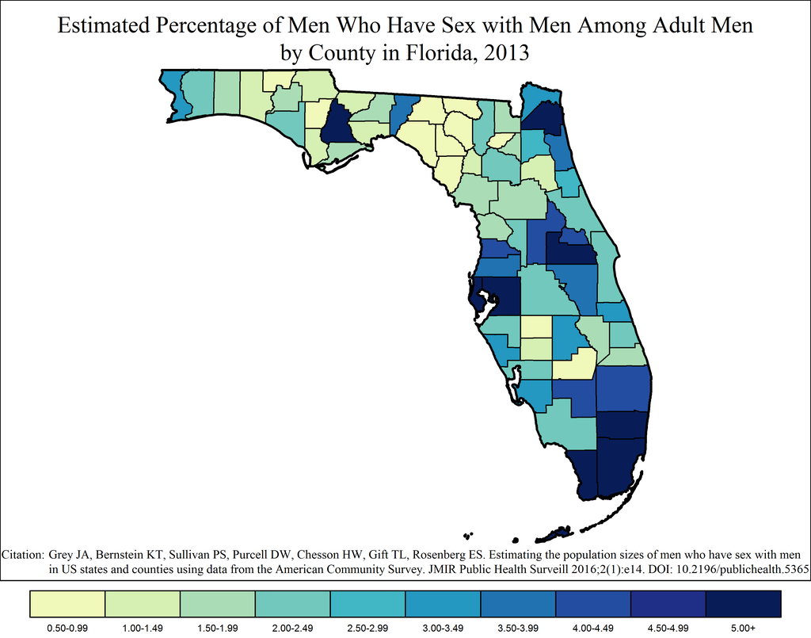

### MSM in Florida Metropolitan Statistical Areas

#### Miami-Fort Lauderdale-West Palm Beach Metropolitan Statistical Area

The Miami-Fort Lauderdale-West Palm Beach MSA had the largest metropolitan population of MSM in Florida at 141,088, or 41.5% of all MSM in the state. Of the 2,131,593 adult men in Miami-Fort Lauderdale-West Palm Beach, an estimated 6.6% were MSM.

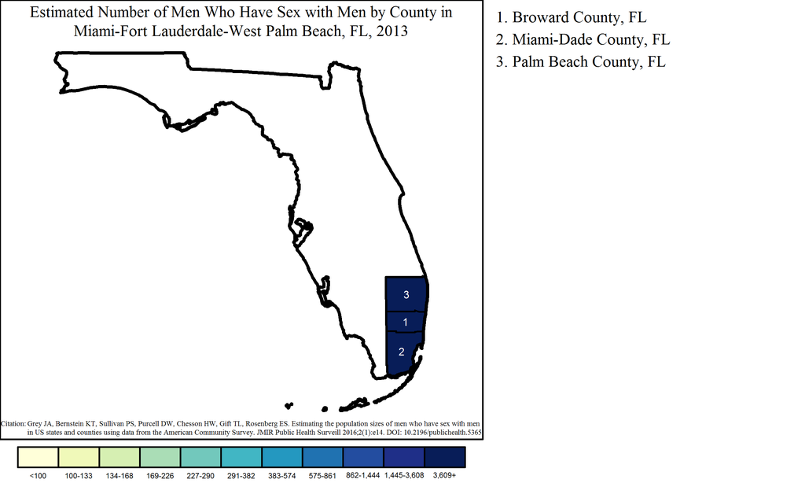

Note: Range cutpoints for the map are based on the distribution of MSM among all counties in the United States.

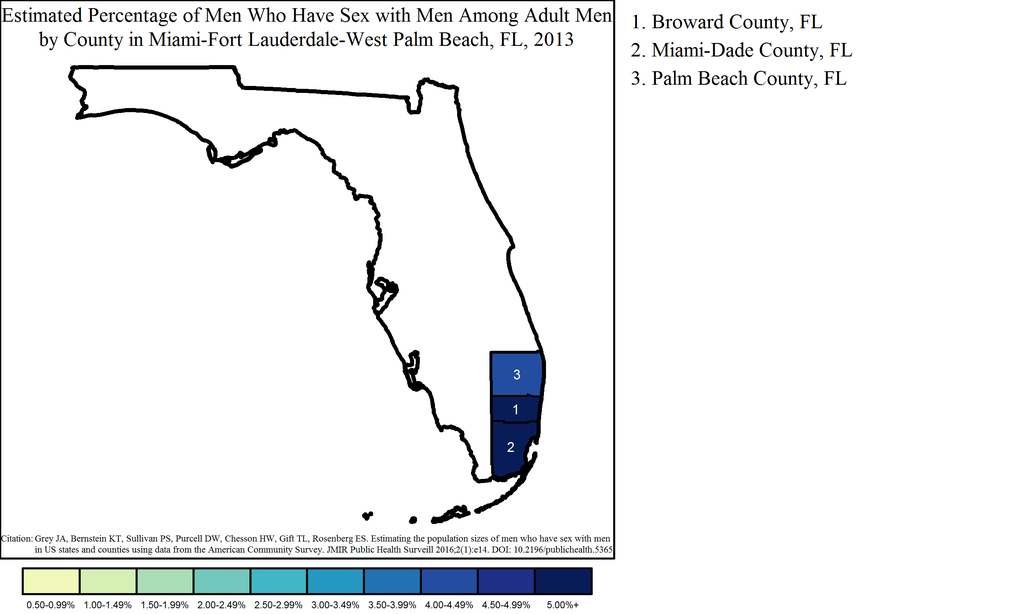

#### Tampa-St. Petersburg-Clearwater Metropolitan Statistical Area

The Tampa-St. Petersburg-Clearwater MSA had a population of 62,726 MSM, or 18.4% of all MSM in Florida. Of the 1,063,472 adult men in Tampa-St. Petersburg-Clearwater, an estimated 5.9% were MSM.

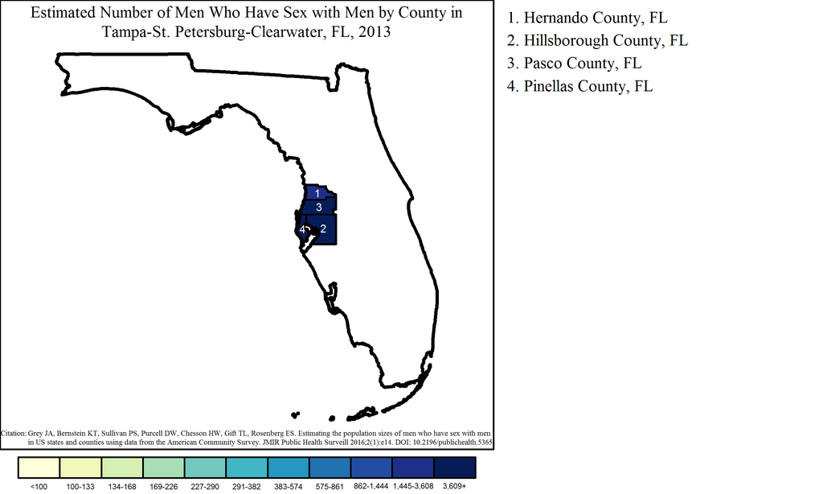

Note: Range cutpoints for the map are based on the distribution of MSM among all counties in the United States.

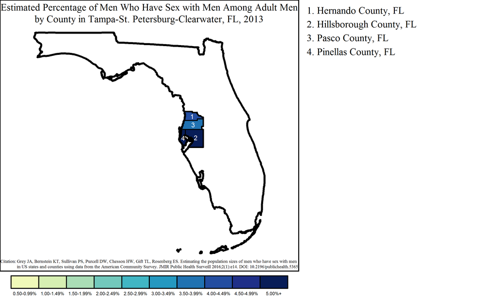

#### Orlando-Kissimmee-Sanford Metropolitan Statistical Area

The Orlando-Kissimmee-Sanford MSA had a population of 45,773 MSM, or 13.5% of all MSM in Florida. Of the 811,483 adult men in Orlando-Kissimmee-Sanford, an estimated 5.6% were MSM.

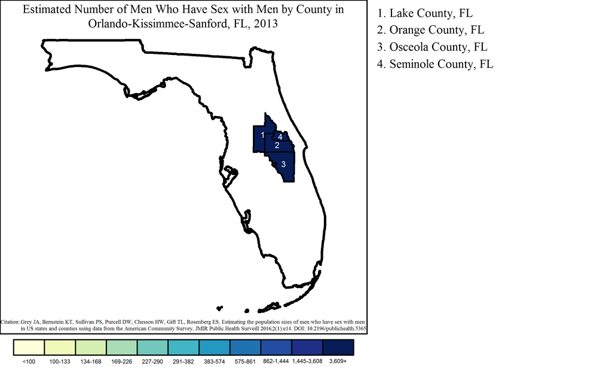

Note: Range cutpoints for the map are based on the distribution of MSM among all counties in the United States.

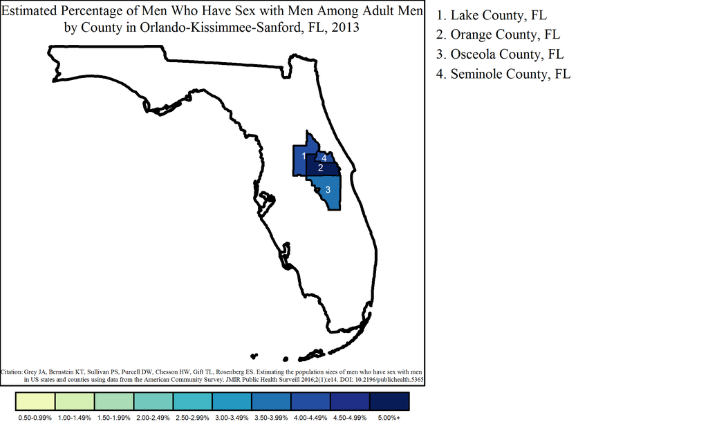

#### Jacksonville Metropolitan Statistical Area

The Jacksonville MSA had a population of 22,116 MSM, or 6.5% of all MSM in Florida. Of the 500,765 adult men in Jacksonville, an estimated 4.4% were MSM.

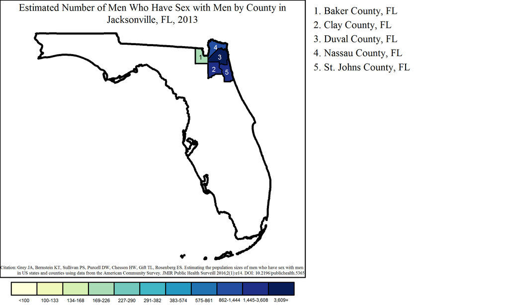

Note: Range cutpoints for the map are based on the distribution of MSM among all counties in the United States.

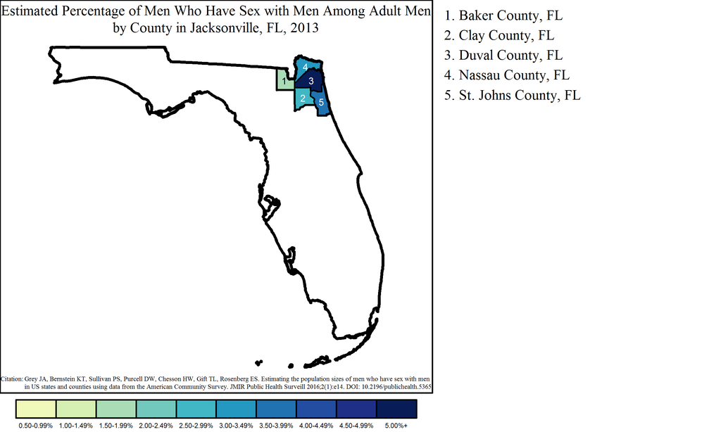

#### North Port-Sarasota-Bradenton Metropolitan Statistical Area

The North Port-Sarasota-Bradenton MSA had a population of 7,872 MSM, or 2.3% of all MSM in Florida. Of the 277,764 adult men in North Port-Sarasota-Bradenton, an estimated 2.8% were MSM.

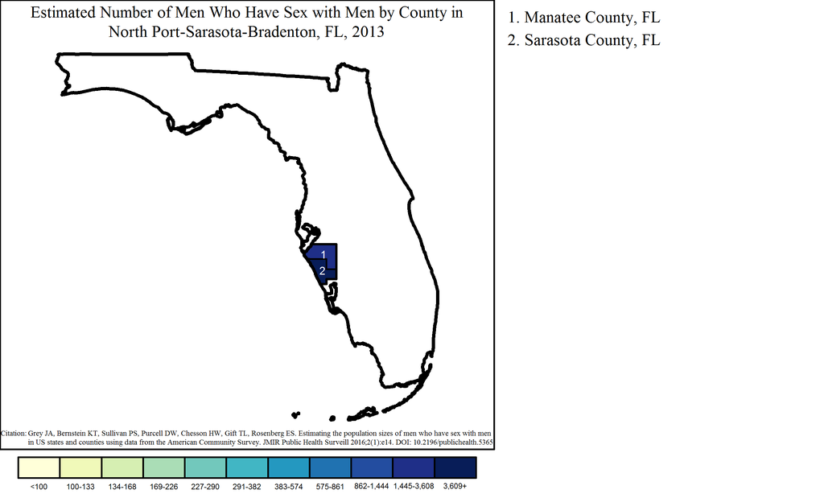

Note: Range cutpoints for the map are based on the distribution of MSM among all counties in the United States.

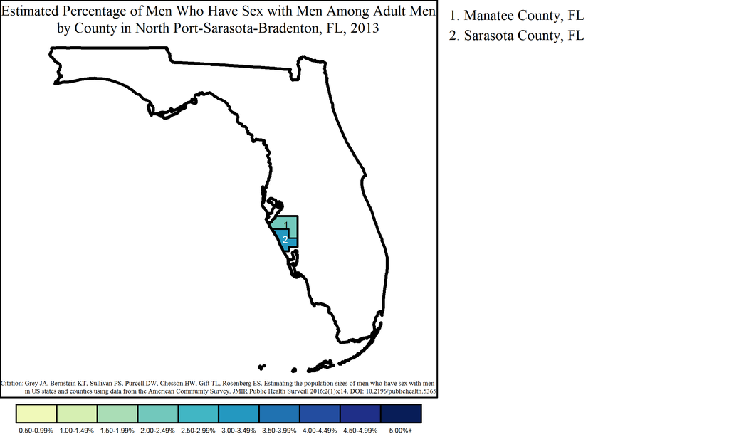

#### Cape Coral-Fort Myers Metropolitan Statistical Area

The Cape Coral-Fort Myers MSA had a population of 7,733 MSM, or 2.3% of all MSM in Florida. Of the 248,375 adult men in Cape Coral-Fort Myers, an estimated 3.1% were MSM.

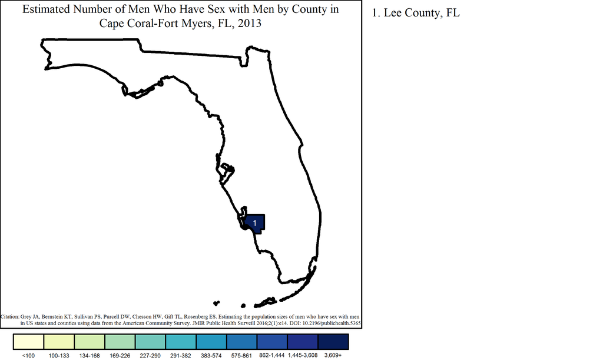

Note: Range cutpoints for the map are based on the distribution of MSM among all counties in the United States.

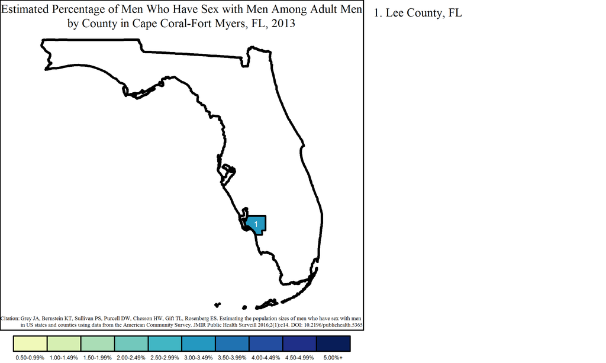

#### Deltona-Daytona Beach-Ormond Beach Metropolitan Statistical Area

The Deltona-Daytona Beach-Ormond Beach MSA had a population of 5,769 MSM, or 1.7% of all MSM in Florida. Of the 231,982 adult men in Deltona-Daytona Beach-Ormond Beach, an estimated 2.5% were MSM.

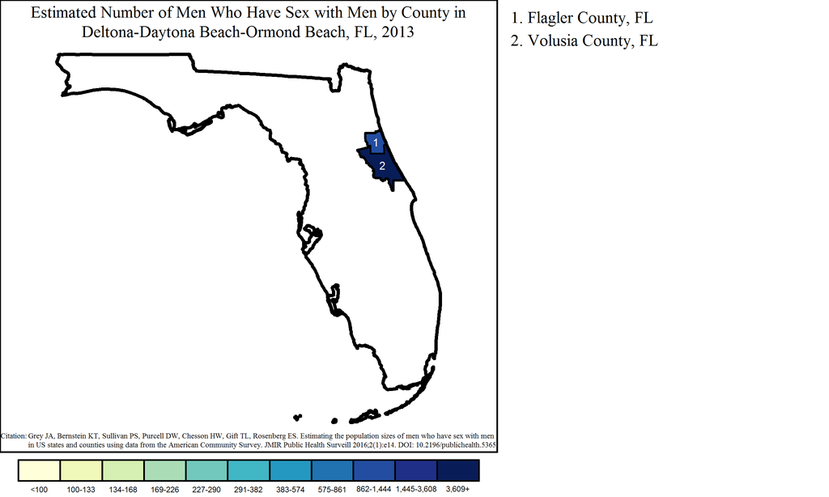

Note: Range cutpoints for the map are based on the distribution of MSM among all counties in the United States.

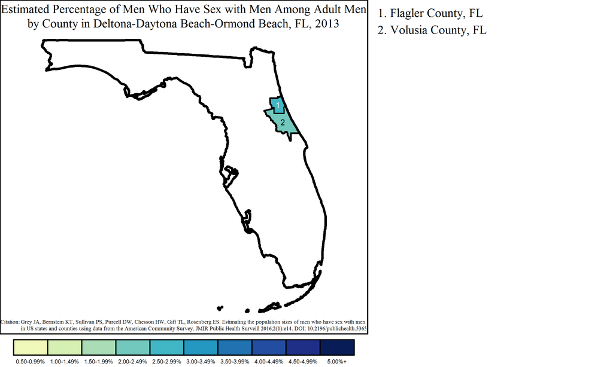

#### Lakeland-Winter Haven Metropolitan Statistical Area

The Lakeland-Winter Haven MSA had a population of 5,555 MSM, or 1.6% of all MSM in Florida. Of the 226,049 adult men in Lakeland-Winter Haven, an estimated 2.5% were MSM.

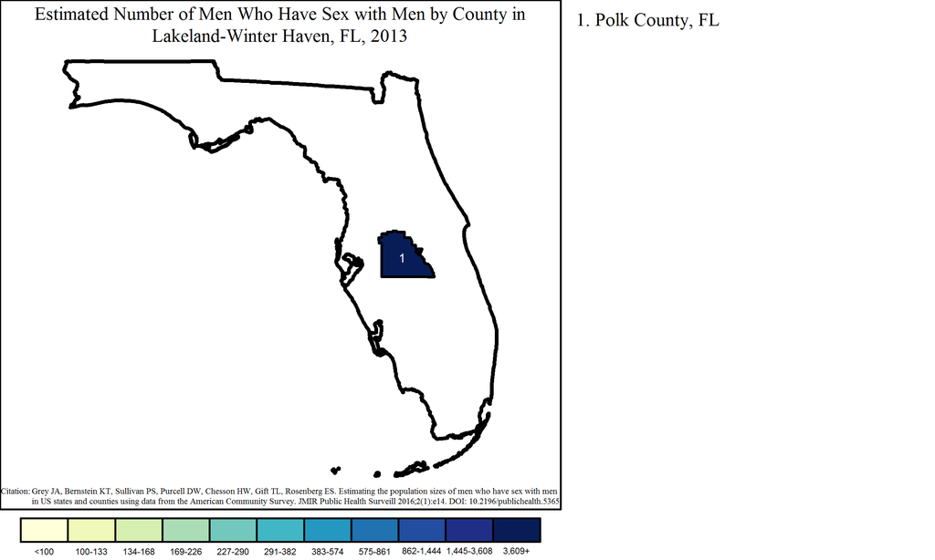

Note: Range cutpoints for the map are based on the distribution of MSM among all counties in the United States.

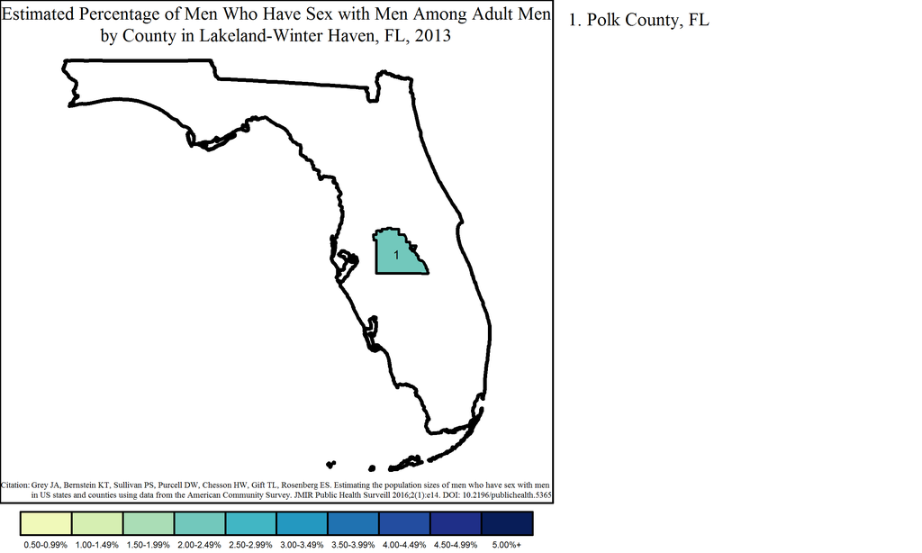

#### Pensacola-Ferry Pass-Brent Metropolitan Statistical Area

The Pensacola-Ferry Pass-Brent MSA had a population of 5,195 MSM, or 1.5% of all MSM in Florida. Of the 176,858 adult men in Pensacola-Ferry Pass-Brent, an estimated 2.9% were MSM.

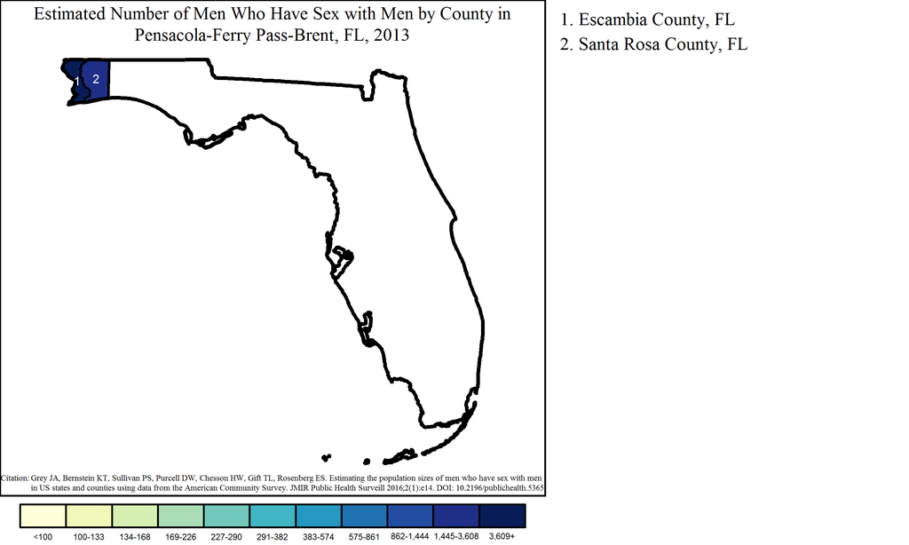

Note: Range cutpoints for the map are based on the distribution of MSM among all counties in the United States.

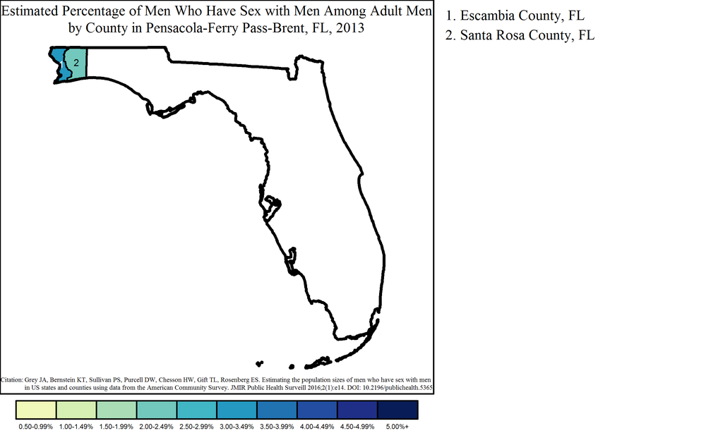

#### Palm Bay-Melbourne-Titusville Metropolitan Statistical Area

The Palm Bay-Melbourne-Titusville MSA had a population of 5,100 MSM, or 1.5% of all MSM in Florida. Of the 212,862 adult men in Palm Bay-Melbourne-Titusville, an estimated 2.4% were MSM.

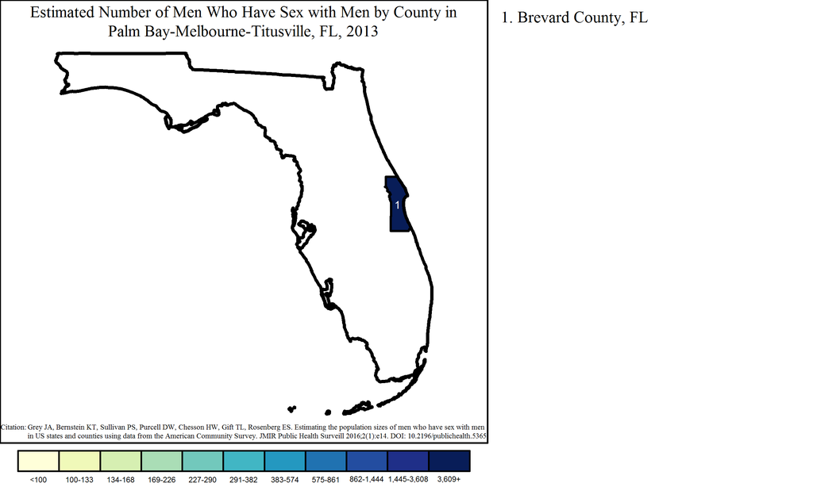

Note: Range cutpoints for the map are based on the distribution of MSM among all counties in the United States.

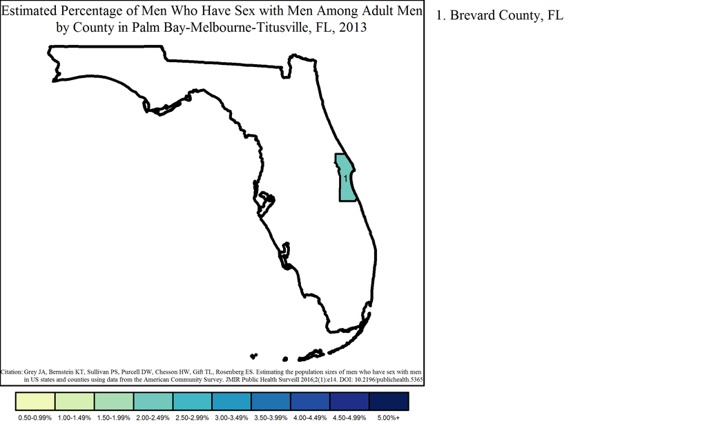

#### Port St. Lucie Metropolitan Statistical Area

The Port St. Lucie MSA had a population of 3,580 MSM, or 1.1% of all MSM in Florida. Of the 165,745 adult men in Port St. Lucie, an estimated 2.2% were MSM.

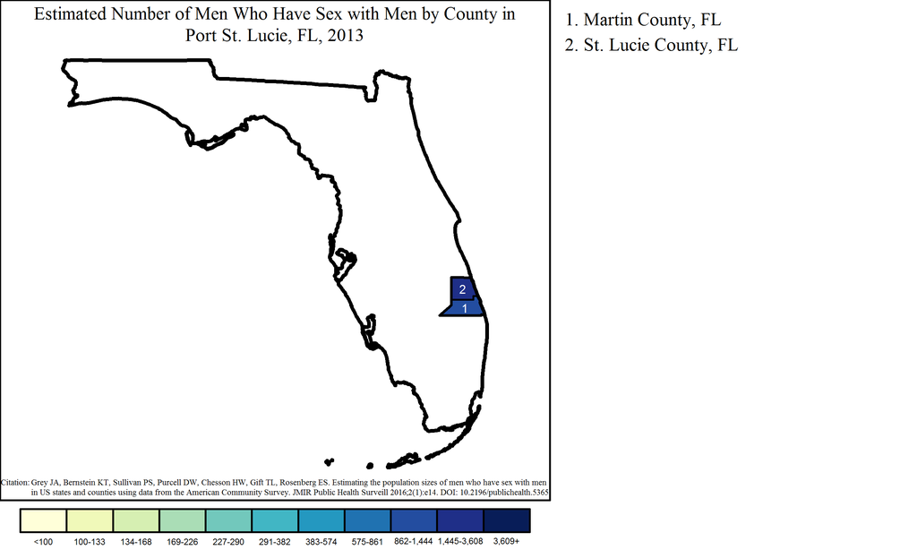

Note: Range cutpoints for the map are based on the distribution of MSM among all counties in the United States.

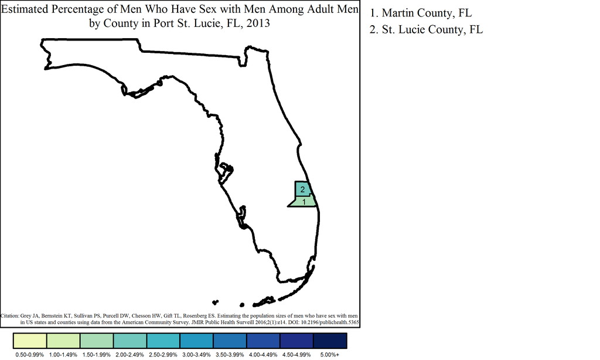

#### Naples-Immokalee-Marco Island Metropolitan Statistical Area

The Naples-Immokalee-Marco Island MSA had a population of 2,861 MSM, or 0.8% of all MSM in Florida. Of the 129,592 adult men in Naples-Immokalee-Marco Island, an estimated 2.2% were MSM.

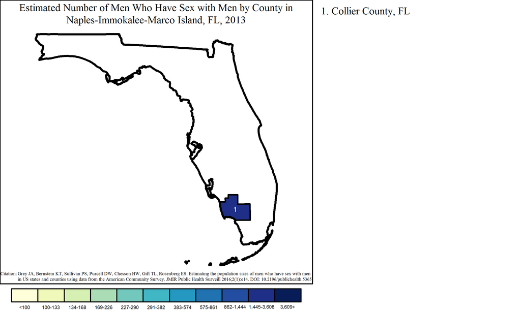

Note: Range cutpoints for the map are based on the distribution of MSM among all counties in the United States.

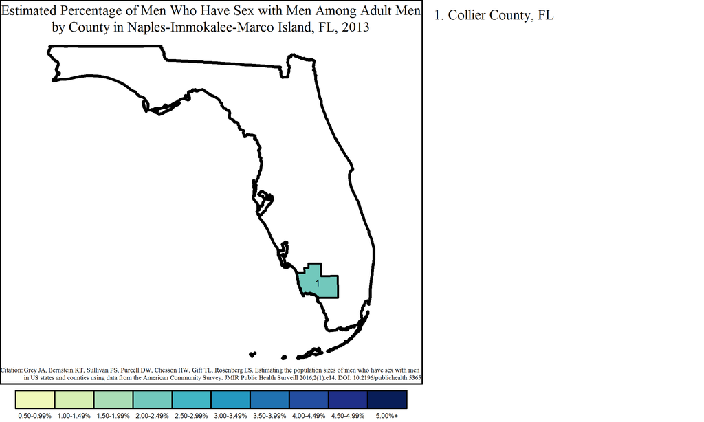

#### Tallahassee Metropolitan Statistical Area

The Tallahassee MSA had a population of 2,645 MSM, or 0.8% of all MSM in Florida. Of the 142,705 adult men in Tallahassee, an estimated 1.9% were MSM.

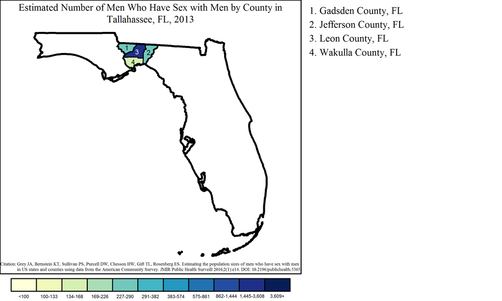

Note: Range cutpoints for the map are based on the distribution of MSM among all counties in the United States.

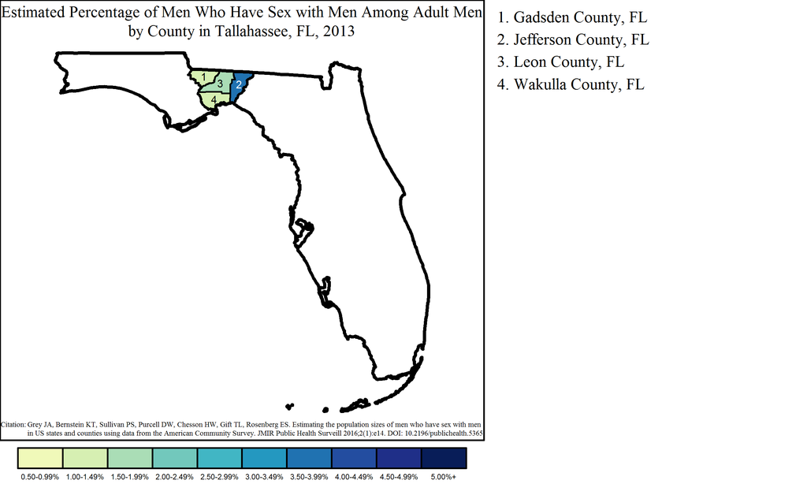

#### Gainesville Metropolitan Statistical Area

The Gainesville MSA had a population of 2,514 MSM, or 0.7% of all MSM in Florida. Of the 104,979 adult men in Gainesville, an estimated 2.4% were MSM.

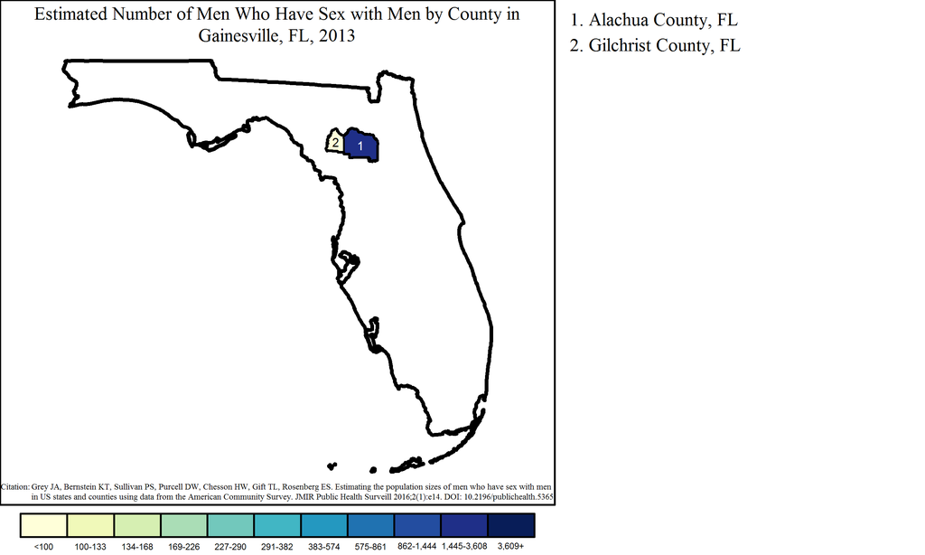

Note: Range cutpoints for the map are based on the distribution of MSM among all counties in the United States.

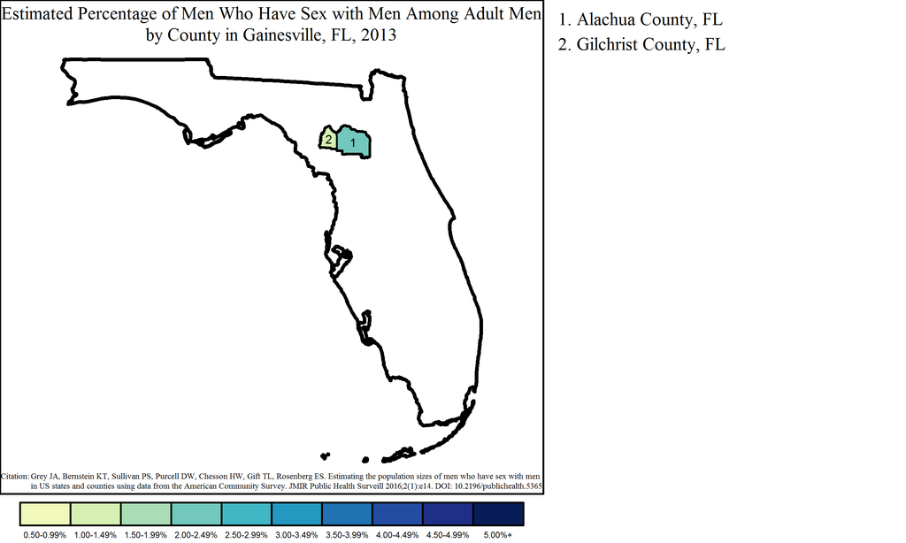